# Single-cell RNA-seq

R

Python

Single-cell RNA-seq

Data Management

This lesson introduces participants to the steps of setting up a single-cell RNA‑seq project. Participants will learn when to consider using scRNA-seq as well as the challenges that scRNA-seq provides.

Authors

Mary Piper

Meeta Mistry

Radhika Khetani

Lorena Pantano

Jihe Liu

Will Gammerdinger

Noor Sohail

Published

May 30, 2025

Keywords

Experimental design, Batch effects

Approximate time: 45 minutes

## Learning objectives

In this lesson, we will:

- Explain why single-cell RNA-seq is used instead of bulk RNA-seq for studying cellular heterogeneity and gene expression at single-cell resolution.
- Identify key biological and technical sources of variability in scRNA-seq data and how they can obscure true cell types or states.
- Assess when scRNA-seq is appropriate for a research question compared to alternatives such as bulk RNA-seq.

## Single-cell RNA-seq

Across human tissues, there is an incredible diversity of cell types, states, and interactions. To better understand these tissues and the cell types present, single-cell RNA-seq (scRNA-seq) offers a glimpse into what genes are being expressed at the level of individual cells.

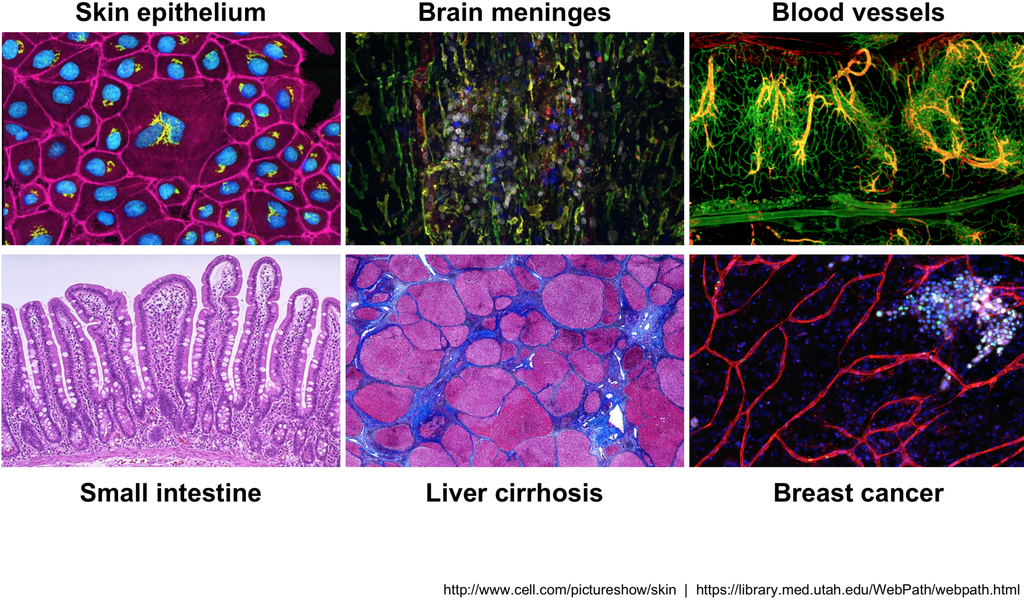

Figure 1: Depiction of the microenvironment found in a variety of different tissues.  
*Image credit:* courtesy of Dr. Ayshwarya Subramanian.

This exciting and cutting-edge method can be used to:

- Explore which cell types are present in a tissue
- Identify unknown/rare cell types or states
- Elucidate the changes in gene expression during differentiation processes or across time or states
- Identify genes that are differentially expressed in particular cell types between conditions (e.g. treatment or disease)
- Explore changes in expression among a cell type while incorporating spatial, regulatory, and/or protein information

Popular methods to address some of the more common investigations include:

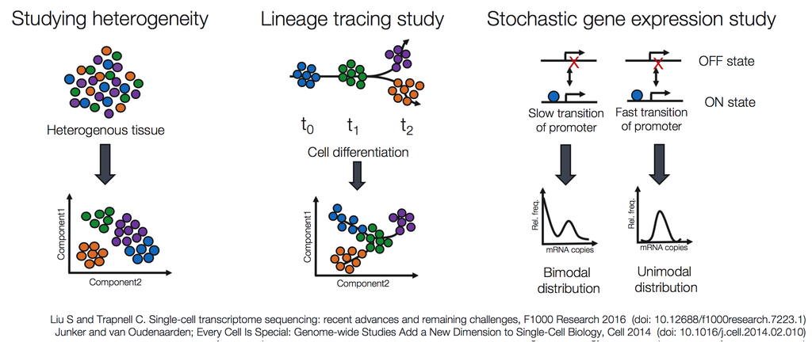

Figure 2: Popular single-cell analyses.

## Challenges of scRNA-seq analysis

Prior to scRNA-seq, transcriptome analysis was performed using **bulk RNA-seq**, which is a method for comparing the **averages of cellular expression**. This method can be a good choice if you are looking at comparative transcriptomics (e.g. samples of the same tissue from different species), and for quantifying expression signatures in disease studies. It also has potential for the discovery of disease biomarkers if you are **not expecting or not concerned about cellular heterogeneity** in the sample.

While bulk RNA-seq can explore differences in gene expression between conditions (e.g. treatment or disease), the differences at the cellular level are not adequately captured. For instance, in the images below, if analyzed in bulk (left), we would not detect the correct association between the expression of gene A and gene B. However, if we properly group the cells by cell type or cell state, we can see the correct correlation between the genes.

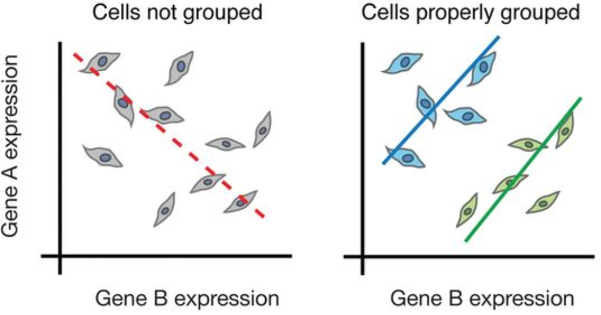

Figure 3: Contrasting how bulk sequencing averages expression against the cellular resolution of single-cell sequencing.  
*Image source:* [Trapnell et al. (2015)](https://dx.doi.org/10.1101/gr.190595.115)

Despite scRNA-seq being able to capture expression at the cellular level, sample generation and library preparation is more expensive and the analysis is much **more complicated and more difficult to interpret**. The complexity of analysis of scRNA-seq data involves:

- Large volume of data
- Low depth of sequencing per cell
- Technical variability across cells/samples
- Biological variability across cells/samples

We will explore each of these complexities in more detail below:

### Large volume of data

Expression data from scRNA-seq experiments represent tens or hundreds of thousands of reads for thousands of cells. The data output is much larger, requiring more memory to analyze, larger storage requirements, and more time to run the analyses.

### Low depth of sequencing per cell

For the droplet-based methods of scRNA-seq, the depth of sequencing is shallow, often detecting only 10-50% of the transcriptome per cell. This results in cells showing zero counts for many of the genes. However, in a particular cell, a zero count for a gene could either mean that the gene was **not being expressed** or the transcripts were just **not detected**. Across cells, genes with higher levels of expression tend to have fewer zeros. Due to this feature, many genes will not be detected in any cell and gene expression will be highly variable between cells.

**Zero-inflated?**

scRNA-seq data is often referred to as zero-inflated; however, recent analyses suggest that it does not contain more zeros than what would be expected given the sequencing depth [[Valentine Svensson’s blog post](http://www.nxn.se/valent/2017/11/16/droplet-scrna-seq-is-not-zero-inflated)]. A more recent paper discussing modeling of scRNA-seq data is also [available](https://www.nature.com/articles/s41588-021-00873-4).

### Biological variability across cells/samples

- **Transcriptional bursting:** Gene transcription is not turned on all of the time for all genes. Time of harvest will determine whether gene is on or off in each cell.
- **Varying rates of RNA processing:** Different RNAs are processed at different rates.
- **Continuous or discrete cell identities (e.g. the pro-inflammatory potential of each individual T cell):** Continuous phenotypes are by definition variable in gene expression, and separating the continuous from the discrete can sometimes be difficult.
- **Environmental stimuli:** The local environment of the cell can influence the gene expression depending on spatial position, signaling molecules, etc.
- **Temporal changes:** Fundamental fluctuating cellular processes, such as cell cycle, can affect the gene expression profiles of individual cells.

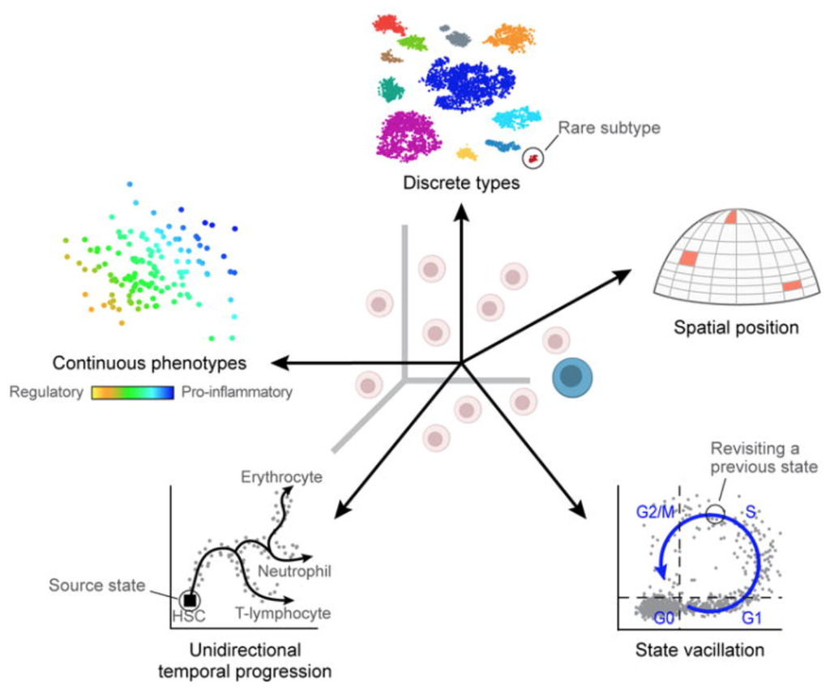

Figure 4: Different sources of variation that can be found in single-cell sequencing experiments.  
*Image source:* [Wagner et al. (2016)](https://dx.doi.org/10.1038%2Fnbt.3711)

## Technical variability across cells/samples

Technical sources of variation can result in gene expression between cells being more similar/different based on technical sources instead of biological cell types/states, which can obscure the cell type identities.

### Sources of technical variation

Technical sources of variation include:

- **Cell-specific capture efficiency:** Different cells will have differing numbers of transcripts captured resulting in differences in sequencing depth (e.g. 10-50% of transcriptome).
- **Library quality:** Degraded RNA, low viability/dying cells, lots of free floating RNA, poorly dissociated cells, and inaccurate quantitation of cells can result in low-quality metrics
- **Amplification bias:** During the amplification step of library preparation, not all transcripts are amplified to the same level.
- **Batch effects:** Batch effects are a significant issue for scRNA-Seq analyses, since you can see significant differences in expression due solely to the batch effect.

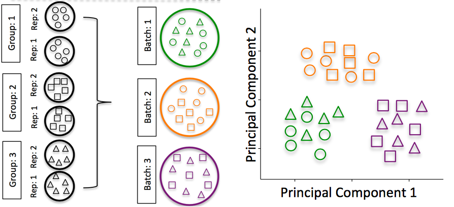

Figure 5: Example PCA, showcasing strong technical batch effect.  
*Image source:* [Hicks et al. (2015)](https://www.biorxiv.org/content/early/2015/08/25/025528)

### Identifying batch

**How to know whether you have batches?**

- Were all RNA isolations performed on the same day?
- Were all library preparations performed on the same day?
- Did the same person perform the RNA isolation/library preparation for all samples?
- Did you use the same reagents for all samples?
- Did you perform the RNA isolation/library preparation in the same location?

If *any* of the answers are **‘No’**, then you have batches.

### Batch best practices

Design the experiment in a way to **avoid batches**, if possible. If you are unable to avoid batches:

**Do NOT confound** your experiment by batch:

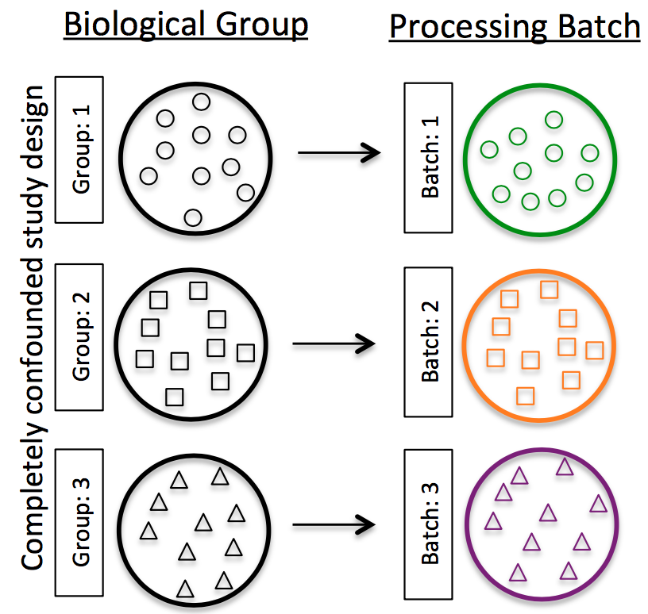

Figure 6: Confounded batch effect.  
*Image source:* [Hicks et al. (2015)](https://www.biorxiv.org/content/early/2015/08/25/025528)

**DO** split replicates of the different sample groups across batches. The more replicates the better (definitely more than 2), if doing DE across conditions or making conclusions at the population level. If using inDrops, which prepares a single library at a time, alternate the sample groups (e.g. don’t prepare all control libraries first and then prepare all treatment libraries).

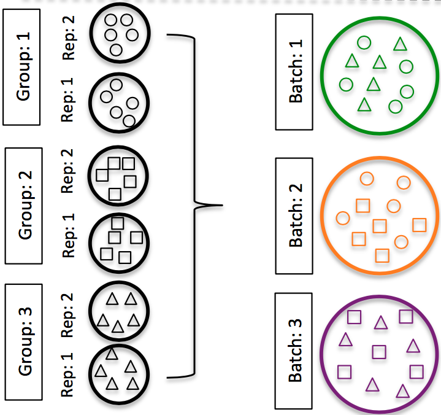

Figure 7: Replicates that are mixed across batches to overcome batch effects.  
*Image source:* [Hicks et al. (2015)](https://www.biorxiv.org/content/early/2015/08/25/025528)

**DO** include batch information in your **experimental metadata**. During the analysis, we can regress out variation due to batch or integrate across batches, so it doesn’t affect our results if we have that information.

## Conclusions

While scRNA-seq is a **powerful and insightful method** for the analysis of gene expression with single-cell resolution, there are **many challenges and sources of variation** that can make the analysis of the data complex or limited. Throughout the analysis of scRNA-seq data, we will try to account for or regress out variation due to the various sources of uninteresting variation in our data.

**Overall, we recommend the following:**

- Do not perform single-cell RNA-seq unless it is necessary for the experimental question of interest. Could you answer the question using bulk sequencing, which is simpler and less costly? Perhaps FACS sorting the samples could allow for bulk analysis?
- Understand the details of the experimental question you wish to address. The recommended library preparation method and analysis workflow can vary based on the specific experiment.
- Avoid technical sources of variability, if possible:
  - Discuss experimental design with experts prior to the initiation of the experiment
  - Isolate RNA from samples at the same time
  - Prepare libraries at the same time or alternate sample groups to avoid batch confounding
  - Do not confound sample groups by sex, age, or batch

**How does single-nucleus RNA-seq (snRNA-seq) compare to single-cell RNA-seq?**

*We will not be covering snRNA-seq in this workshop!* Below is a brief overview of snRNA-seq.

snRNA-seq analyzes the expression profiles from nuclei, instead of intact cells. As you may expect, fewer transcripts are detected from the nuclei (~7,000 genes), compared to intact cells (~11,000 genes). In some situations (depending on your research materials and goals), snRNA-seq can be the preferred method as opposed to scRNA-seq.

Some advantages of snRNA-seq include: - Works well with hard-to-isolate samples (for example, adipocytes), as well as frozen tissues - Reduces transcriptional artifacts from the isolation process - Provides less biased cellular coverage

Next Lesson >>

Back to Schedule